# Convertible vs. Wagon

```r
CarPrices1 <- CarPrices %>% filter(Type == c("Convertible","Wagon"))
```

```r
CarPrices1lm <- lm(Price ~ Mileage + Type + Mileage:Type, data=CarPrices1)
```

## Background

Two cars that are very different are a convertible and a wagon. They may be different and because of that I am interested in seeing how the prices will vary over mileage.

$$\text{Which car has a better value when compared with mileage?}$$

While you may initially think that a convertible is fancy and that a wagon is classy, there may be a comparison in the types of cars that could add some really interesting insights.

## The Data

### Hide

A data set was able to be obtained, which lists car types, prices, and many other variables. If you are interested in seeing that data, then you can see the data here!

### Show

```r
pander(CarPrices1)
```

Table continues below

| Price | Mileage | Make | Model | Trim | Type |
| --- | --- | --- | --- | --- | --- |
| 70755 | 583 | Cadillac | XLR-V8 | Hardtop Conv 2D | Convertible |
| 69134 | 7892 | Cadillac | XLR-V8 | Hardtop Conv 2D | Convertible |
| 65281 | 15600 | Cadillac | XLR-V8 | Hardtop Conv 2D | Convertible |
| 60568 | 23193 | Cadillac | XLR-V8 | Hardtop Conv 2D | Convertible |
| 55639 | 31805 | Cadillac | XLR-V8 | Hardtop Conv 2D | Convertible |
| 46733 | 3625 | Chevrolet | Corvette | Conv 2D | Convertible |
| 44750 | 12115 | Chevrolet | Corvette | Conv 2D | Convertible |
| 41371 | 20000 | Chevrolet | Corvette | Conv 2D | Convertible |
| 39692 | 25169 | Chevrolet | Corvette | Conv 2D | Convertible |
| 36971 | 30502 | Chevrolet | Corvette | Conv 2D | Convertible |
| 16034 | 18391 | Pontiac | Vibe | AWD Sportwagon 4D | Wagon |
| 16551 | 19531 | Pontiac | Vibe | AWD Sportwagon 4D | Wagon |
| 16079 | 22779 | Pontiac | Vibe | AWD Sportwagon 4D | Wagon |
| 15505 | 24239 | Pontiac | Vibe | AWD Sportwagon 4D | Wagon |
| 14547 | 33374 | Pontiac | Vibe | AWD Sportwagon 4D | Wagon |
| 16353 | 16078 | Pontiac | Vibe | GT Sportwagon | Wagon |
| 15569 | 18206 | Pontiac | Vibe | GT Sportwagon | Wagon |
| 15730 | 21391 | Pontiac | Vibe | GT Sportwagon | Wagon |
| 15087 | 27438 | Pontiac | Vibe | GT Sportwagon | Wagon |
| 14869 | 31791 | Pontiac | Vibe | GT Sportwagon | Wagon |
| 17418 | 4463 | Pontiac | Vibe | Sportwagon 4D | Wagon |
| 16707 | 9150 | Pontiac | Vibe | Sportwagon 4D | Wagon |
| 15822 | 14304 | Pontiac | Vibe | Sportwagon 4D | Wagon |
| 15622 | 23217 | Pontiac | Vibe | Sportwagon 4D | Wagon |
| 14853 | 24270 | Pontiac | Vibe | Sportwagon 4D | Wagon |
| 35622 | 10340 | SAAB | 9_3 | Linear Conv 2D | Convertible |
| 34355 | 17711 | SAAB | 9_3 | Linear Conv 2D | Convertible |
| 33541 | 20925 | SAAB | 9_3 | Linear Conv 2D | Convertible |
| 33287 | 21661 | SAAB | 9_3 | Linear Conv 2D | Convertible |
| 31969 | 24559 | SAAB | 9_3 | Linear Conv 2D | Convertible |
| 37089 | 3828 | SAAB | 9_3 HO | Aero Conv 2D | Convertible |
| 33359 | 17590 | SAAB | 9_3 HO | Aero Conv 2D | Convertible |
| 30732 | 22479 | SAAB | 9_3 HO | Aero Conv 2D | Convertible |
| 30167 | 25049 | SAAB | 9_3 HO | Aero Conv 2D | Convertible |
| 29143 | 31655 | SAAB | 9_3 HO | Aero Conv 2D | Convertible |
| 38325 | 12090 | SAAB | 9_3 HO | Arc Conv 2D | Convertible |
| 37384 | 16088 | SAAB | 9_3 HO | Arc Conv 2D | Convertible |
| 35580 | 21167 | SAAB | 9_3 HO | Arc Conv 2D | Convertible |
| 34393 | 24031 | SAAB | 9_3 HO | Arc Conv 2D | Convertible |
| 33248 | 27051 | SAAB | 9_3 HO | Arc Conv 2D | Convertible |
| 32650 | 16975 | SAAB | 9_5 | Arc Wagon 4D | Wagon |
| 31554 | 20103 | SAAB | 9_5 | Arc Wagon 4D | Wagon |
| 30575 | 22298 | SAAB | 9_5 | Arc Wagon 4D | Wagon |
| 28678 | 25380 | SAAB | 9_5 | Arc Wagon 4D | Wagon |
| 26955 | 31773 | SAAB | 9_5 | Arc Wagon 4D | Wagon |
| 30661 | 14278 | SAAB | 9_5 | Linear Wagon 4D | Wagon |
| 30322 | 16225 | SAAB | 9_5 | Linear Wagon 4D | Wagon |
| 31085 | 18187 | SAAB | 9_5 | Linear Wagon 4D | Wagon |
| 29115 | 21960 | SAAB | 9_5 | Linear Wagon 4D | Wagon |
| 24903 | 40719 | SAAB | 9_5 | Linear Wagon 4D | Wagon |
| 29987 | 18464 | SAAB | 9_5 HO | Aero Wagon 4D | Wagon |
| 28328 | 20685 | SAAB | 9_5 HO | Aero Wagon 4D | Wagon |
| 29321 | 21545 | SAAB | 9_5 HO | Aero Wagon 4D | Wagon |
| 26792 | 25357 | SAAB | 9_5 HO | Aero Wagon 4D | Wagon |
| 26012 | 34269 | SAAB | 9_5 HO | Aero Wagon 4D | Wagon |
| 25959 | 17431 | SAAB | 9-2X AWD | Linear Wagon 4D | Wagon |
| 23329 | 25218 | SAAB | 9-2X AWD | Linear Wagon 4D | Wagon |

| Cylinder | Liter | Doors | Cruise | Sound | Leather |
| --- | --- | --- | --- | --- | --- |
| 8 | 4.6 | 2 | 1 | 1 | 1 |
| 8 | 4.6 | 2 | 1 | 1 | 1 |
| 8 | 4.6 | 2 | 1 | 1 | 1 |
| 8 | 4.6 | 2 | 1 | 1 | 1 |
| 8 | 4.6 | 2 | 1 | 0 | 1 |
| 8 | 6 | 2 | 1 | 1 | 1 |
| 8 | 6 | 2 | 1 | 0 | 1 |
| 8 | 6 | 2 | 1 | 0 | 1 |
| 8 | 6 | 2 | 1 | 1 | 1 |
| 8 | 6 | 2 | 1 | 1 | 1 |
| 4 | 1.8 | 4 | 0 | 1 | 1 |
| 4 | 1.8 | 4 | 1 | 1 | 1 |
| 4 | 1.8 | 4 | 0 | 0 | 1 |
| 4 | 1.8 | 4 | 1 | 0 | 0 |
| 4 | 1.8 | 4 | 0 | 1 | 1 |
| 4 | 1.8 | 4 | 0 | 1 | 0 |
| 4 | 1.8 | 4 | 0 | 0 | 0 |
| 4 | 1.8 | 4 | 0 | 1 | 1 |
| 4 | 1.8 | 4 | 0 | 0 | 1 |
| 4 | 1.8 | 4 | 1 | 1 | 1 |
| 4 | 1.8 | 4 | 1 | 0 | 1 |
| 4 | 1.8 | 4 | 0 | 0 | 0 |
| 4 | 1.8 | 4 | 0 | 0 | 1 |
| 4 | 1.8 | 4 | 1 | 1 | 1 |
| 4 | 1.8 | 4 | 0 | 0 | 0 |
| 4 | 2 | 2 | 1 | 1 | 0 |
| 4 | 2 | 2 | 1 | 1 | 0 |
| 4 | 2 | 2 | 1 | 0 | 1 |
| 4 | 2 | 2 | 1 | 0 | 1 |
| 4 | 2 | 2 | 1 | 0 | 0 |
| 4 | 2 | 2 | 1 | 1 | 1 |
| 4 | 2 | 2 | 1 | 1 | 1 |
| 4 | 2 | 2 | 1 | 0 | 0 |
| 4 | 2 | 2 | 1 | 0 | 0 |
| 4 | 2 | 2 | 1 | 1 | 1 |
| 4 | 2 | 2 | 1 | 1 | 1 |
| 4 | 2 | 2 | 1 | 0 | 1 |
| 4 | 2 | 2 | 1 | 1 | 0 |
| 4 | 2 | 2 | 1 | 0 | 1 |
| 4 | 2 | 2 | 1 | 0 | 1 |
| 4 | 2.3 | 4 | 1 | 1 | 1 |
| 4 | 2.3 | 4 | 1 | 1 | 1 |
| 4 | 2.3 | 4 | 1 | 1 | 1 |
| 4 | 2.3 | 4 | 1 | 0 | 1 |
| 4 | 2.3 | 4 | 1 | 0 | 1 |
| 4 | 2.3 | 4 | 1 | 0 | 1 |
| 4 | 2.3 | 4 | 1 | 1 | 1 |
| 4 | 2.3 | 4 | 1 | 1 | 1 |
| 4 | 2.3 | 4 | 1 | 0 | 1 |
| 4 | 2.3 | 4 | 1 | 1 | 1 |
| 4 | 2.3 | 4 | 1 | 0 | 1 |
| 4 | 2.3 | 4 | 1 | 0 | 1 |
| 4 | 2.3 | 4 | 1 | 0 | 1 |
| 4 | 2.3 | 4 | 1 | 0 | 1 |
| 4 | 2.3 | 4 | 1 | 1 | 1 |
| 4 | 2.5 | 4 | 1 | 0 | 1 |
| 4 | 2.5 | 4 | 1 | 0 | 1 |

## Limitations

When performing a Multiple Linear Regression, like other parametric tests, certain assumptions need to be checked.

1.**Linear Relation**

2.**Normal Errors**

3.**Constant Variance**

4.**Fixed X**

5.**Independent Errors**

I will use a QQ plot and other charts to check the assumptions that are necessary.

### Residual versus Fitted-values

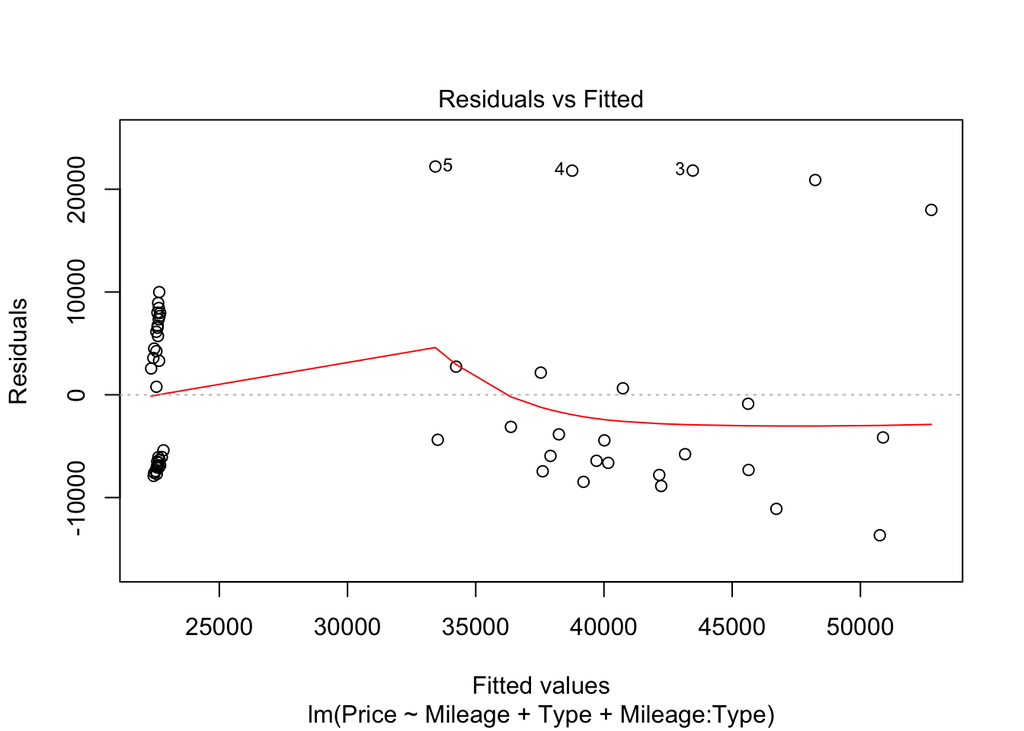

```r
plot(CarPrices1lm, which=1)
```

This plot checks to see if assumptions 1 and 3 are met. Both of these would be met if there was not a pattern in this plot. There is a pattern in this plot and so these assumptions are not met.

### Q-Q Plot of the Residuals

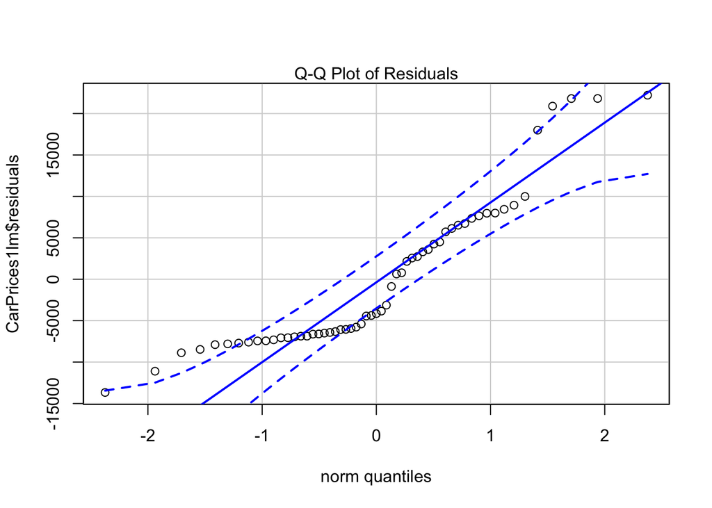

```r
qqPlot(CarPrices1lm$residuals, id=FALSE)
mtext(side=3,text="Q-Q Plot of Residuals")
```

The Q-Q plot of residuals shows most of the dots to be within the dashed lines showing normality. There are 5 dots that you can see that are outside of the lines. I’d say that this is normal because there weren’t that many outside of the lines. This means that assumption #2 is satisfied.

### Residuals versus Order Plot

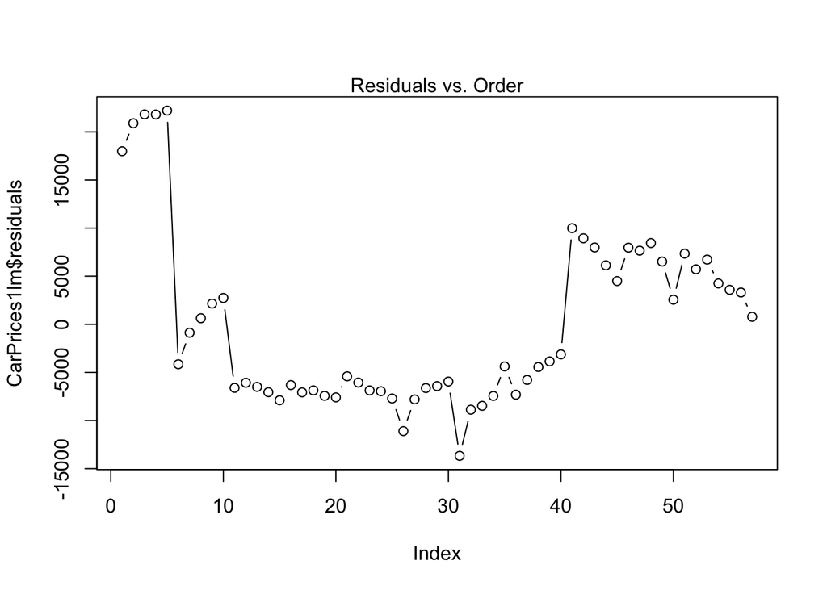

```r
plot(CarPrices1lm$residuals, type="b")
mtext(side=3, text="Residuals vs. Order")
```

There is a dramatic trend in the data. It is following an order and so that means that assumption #5 is not met.

The assumptions that you can trust to be correct would be.

2.**Normal Errors**

4.**Fixed X**

(This one is true because the x variable is fixed)

Even though not all of the assumptions are met, we will continue on with the analysis.

## Analysis

In a multiple linear regression you will usually need a “model”, to help guide through the thought process and understand what is going on.

### Short version

$$Y_i = \beta_0 + \beta_1 X_{i1} + \beta_2 X_{i2} + \beta_3 X_{i1} X_{i2} + \epsilon_i$$

### Long version

$$\underbrace{Y_i}_\text{Price} = \overbrace{\underbrace{\beta_0}_{\text{Y-intercept}} + \underbrace{\beta_1}_{\text{Slope}} \underbrace{X_{i1}}_{\text{Mileage}}}^{\text{Convertible}} + \underbrace{\beta_2}_{\text{Change in Y-intercept}}* \underbrace{X_{i2}}_{\text{Model type}} + \underbrace{\beta_3}_{\text{The change in slope}} \overbrace{X_{i1}X_{i2}}^{\text{Wagon adjustments to line}} + \underbrace{\epsilon_i}_{\text{error}}$$

$$\text{Where we still assume}~\epsilon_i \sim N(0,\sigma^2)$$

```r
pander(summary(CarPrices1lm))
```

|  | Estimate | Std. Error | t value | Pr(>\|t\|) |
| --- | --- | --- | --- | --- |
| **(Intercept)** | 53127 | 4438 | 11.97 | 1.085e-16 |
| **Mileage** | -0.6194 | 0.2162 | -2.864 | 0.005976 |
| **TypeWagon** | -30245 | 6834 | -4.425 | 4.83e-05 |
| **Mileage:TypeWagon** | 0.6062 | 0.3126 | 1.939 | 0.05783 |

Fitting linear model: Price ~ Mileage + Type + Mileage:Type

| Observations | Residual Std. Error | $R^2$ | Adjusted $R^2$ |
| --- | --- | --- | --- |
| 57 | 9222 | 0.5605 | 0.5357 |

[figure not shown]

```r
palette(c("skyblue","red"))

plot(Price ~ Mileage, col=as.factor(Type), data=CarPrices1,pch=16, main="Cost and Depreciation Comparison \n Convertible vs. Wagon", ylab="Listing Price of the Vehicle", xlab="Mileage of the Vehicle", yaxt="n", xaxt="n", xlim=c(0,50000), ylim=c(0,100000))

axis(1, at=c(10000, 20000, 30000, 40000, 50000), labels=c("20,000","40,000","60,000","40,000","50,000"), col.axis="gray55")

axis(2, at=c(20000, 40000, 60000, 80000, 100000), labels=c("20k","40k","60k","80k","100k"), col.axis="gray55", las=2)
```